# Three or More Predictors

Yan Zhu

2025-01-04

# Conceptual Questions

## 1.

A researcher presents the following equation representing the relationship between the number of books a child reads and whether or not that child has a diagnosis of dyslexia, where dyslexia is coded 1 (does not have dyslexia) and -1 (has dyslexia):

Books = 1.52 + 0.5 * dyslexia.

If the researcher recoded dyslexia as -.5 (does not have dyslexia) and .5 (has dyslexia), what would be the new regression equation representing the predicted number of books a child reads?

> 1.52 - 1 * dyslexia

## 2.

In a mediation analysis, what is meant by the “direct effect”? Why is this term potentially misleading?

> The direct effect is the effect of X on Y statistically controlling for M. This term implies that X acts directly on Y, but this may not be the case. There could be other mediators of the relationship between X and Y that you are not including in your model. Thus, in reality the direct effect may not reflect a true direct effect of X on Y.

## 3.

What is our measurement of the total prediction error associated with a given model? In the context of testing statistical models, what does it mean to “reduce error?”

> The sum of squared errors (SSE) is our measure of the total prediction error associated with a given model. When you reduce error in a statistical model you are accounting for additional variance in your outcome variable, and thus the augmented model has a lower SSE than the compact model.

## 4.

What does it mean for an estimate to be “unbiased”? What is our estimate for the population mean? Is this estimate biased or unbiased? What is our estimate for the population SD?

> An estimate is unbiased if the error is random (not systematic) and the value of the estimate is equal to the peak and average for the sampling distribution. An unbiased estimate does not systematically over-or under-estimate the population parameter. The sample mean is our estimate of the population mean, and it is an unbiased estimate. Similarly, square root of the mean squared error (RMSE) is the best estimate of the population standard deviation. For the simple or mean-only model that we discussed in class the RMSE is the sample standard deviation, which is our best estimate of the population standard deviation.

## 5.

### A.

Imagine you are at a conference when you see someone present a mediation model. Their model indicates that the relationship between extraversion and the likelihood of agreeing to attend an unknown event (measured continuously) is mediated by mood. Assume that participants answered all questions (including whether they would attend the event) in the same survey. Is this an appropriate design to test for mediation?

> No, mediation is best applied when we can determine the direction of an effect (x cases m, m causes y).

### B.

The researcher in part A reports that extraversion significantly predicts the likelihood of attending the unknown event, b1 = 3.5. Further the researcher reports that extraversion predicts having a more positive mood, b1 = 0.6. Finally, when controlling for the effects of extraversion, mood significantly predicts the likelihood that someone attends the event, b1 = 2.50. Oops! The researcher forgot to report one estimate from their mediation model. What did they forget to report? Calcuate the value of that effect.

> The total effect = 3.5, path a = 0.6, path b = 2.5. They have not reported the direct effect which can be calculated from c (the total effect) - ab. 3.5 - (.6 * 2.5) = 2.

# Data Analysis

## 1.

Read the data into R and inspect them. Based on descriptive statistics and univariate plots, are there any hints that some cases might have been miscoded and should be excluded?

```r
d <- read_csv("/Users/yanzhu/Desktop/sample_code/Design and Analysis of Psychological Experiments/Data/hw_07_data_2023.csv")
```

```r
describe(d)
```

```
##            vars   n  mean     sd median trimmed  mad min     max   range  skew
## team*         1 209  1.50   0.50   1.00    1.50 0.00   1    2.00    1.00  0.01
## gender*       2 209  1.52   0.50   2.00    1.52 0.00   1    2.00    1.00 -0.07
## laughter1     3 209  6.31   4.48   5.48    5.89 4.39   0   23.56   23.56  0.99
## laughter2     4 209  6.93   4.44   6.51    6.62 4.55   0   19.74   19.74  0.62
## laughter3     5 209  7.35   5.02   6.71    6.94 5.05   0   20.87   20.87  0.65
## laughter4     6 209  6.39   4.45   5.41    6.03 4.32   0   20.13   20.13  0.73
## laughter5     7 209  6.90   4.84   5.82    6.51 4.68   0   23.75   23.75  0.76
## laughter6     8 209  0.36   0.56   0.00    0.25 0.00   0    2.31    2.31  1.63
## laughter7     9 209  6.59   4.69   5.85    6.12 4.17   0   21.97   21.97  0.88
## liking       10 209  2.72   1.36   2.76    2.66 1.47   0    7.00    7.00  0.45
## similarity   11 209  2.73   1.76   2.61    2.67 1.97   0    7.00    7.00  0.27
## drinks       12 209 38.97 483.83   6.00    5.53 2.97   0 7000.00 7000.00 14.25
##            kurtosis    se
## team*         -2.01  0.03
## gender*       -2.01  0.03
## laughter1      0.97  0.31
## laughter2     -0.07  0.31
## laughter3     -0.15  0.35
## laughter4      0.03  0.31
## laughter5      0.09  0.33
## laughter6      1.88  0.04
## laughter7      0.29  0.32
## liking         0.17  0.09
## similarity    -0.72  0.12
## drinks       202.02 33.47
```

There was definitely some sort of error with the drinks variable, which has a max of 7,000. Yikes! Let’s see the distribution.

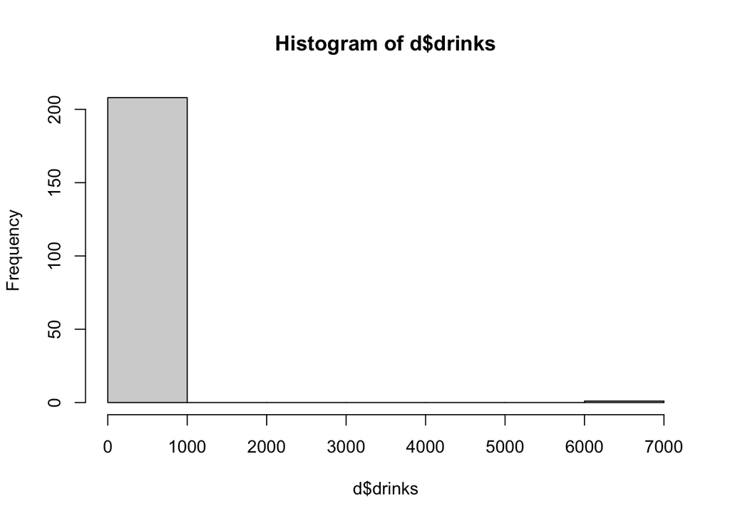

```r
hist(d$drinks)
```

It looks like there’s just one person who is an extreme outlier. We’ll want to exclude this case. I’m a bit suspicious that something is wrong with the “laughter 6” variable, because the max is so low. Let’s look at that too.

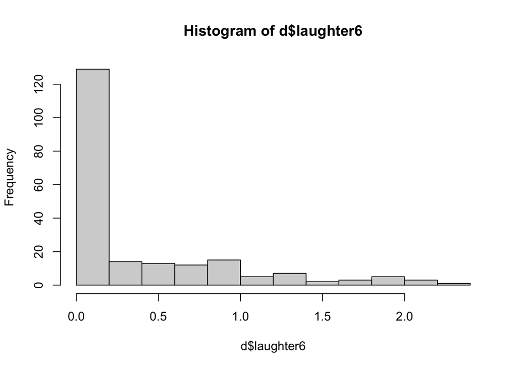

```r
hist(d$laughter6)
```

The modal laugh time was 0 seconds here, and those who did were mostly laughing for less than 1 second. Maybe this was just a really non-funny clip, worthy of only a single brief chuckle for some people.

## 2.

Observations in this dataframe should have unique identifiers. Create a variable called pair_id (an id for each observation in the dataset) that ranges from “p1001” to “p1209”. Reorder your variables so this id is in the first column. Google it if you need help with any of this data wrangling. Str_c(), paste(), and select() are three functions that might help you get the job done

```r
# creating a new pair_id variable.
# this str_c function is in "stringr," a tidyverse package:
d$team_id <- str_c("p", 1001:1209)

# here's an alternative way to do it with the "paste" function:
# d$team_id <- paste("p", 1001:1209, sep = "")

# here's another alternative using the seq command:
#d$team_id <- paste("p", seq(1001, 1210, by = 1), sep = "")

# here's another way to reorder columns.
d <- d %>% dplyr::select(team_id, everything())
```

## 3.

Exclude any cases that have clearly been miscoded. While in your own data you might look further into this miscoding to see if you can fix it, for the purposes of this assignment, simply remove the entire pair when you find evidence of clear miscoding. Do a quick check for any additional miscoded values.

```r
d <- d[d$drinks < 19,] # 18 is the max in the codebook
```

## 4.

Focus on the variables measuring laughter during each video clip (i.e., laughter1-7).

### A.

Determine the reliability of the clips. Assume for this question only that these clips were used in a previous study and using them to elicit laughter is a standardized procedure. Are there any clips that should not be included in the composite score? Write a short comment explaining your reasoning.

```r
d %>% dplyr::select(contains("laugh")) %>% psych::alpha()
```

```
## Number of categories should be increased  in order to count frequencies.
```

```
##
## Reliability analysis
## Call: psych::alpha(x = .)
##
##   raw_alpha std.alpha G6(smc) average_r S/N   ase mean  sd median_r
##       0.75      0.71    0.71      0.26 2.5 0.024  5.8 2.7     0.33
##
##     95% confidence boundaries
##          lower alpha upper
## Feldt      0.7  0.75   0.8
## Duhachek   0.7  0.75   0.8
##
##  Reliability if an item is dropped:
##           raw_alpha std.alpha G6(smc) average_r S/N alpha se  var.r med.r
## laughter1      0.73      0.68    0.68      0.26 2.1    0.026 0.0389  0.34
## laughter2      0.70      0.65    0.65      0.24 1.9    0.029 0.0327  0.32
## laughter3      0.69      0.64    0.64      0.23 1.8    0.029 0.0332  0.32
## laughter4      0.71      0.67    0.66      0.26 2.1    0.028 0.0261  0.32
## laughter5      0.72      0.67    0.67      0.25 2.0    0.027 0.0358  0.33
## laughter6      0.77      0.77    0.75      0.36 3.4    0.024 0.0038  0.37
## laughter7      0.71      0.65    0.65      0.24 1.9    0.028 0.0366  0.32
##
##  Item statistics
##             n raw.r std.r r.cor r.drop mean   sd
## laughter1 208 0.620  0.62 0.509  0.441 6.33 4.49
## laughter2 208 0.705  0.69 0.631  0.554 6.90 4.44
## laughter3 208 0.738  0.72 0.677  0.577 7.30 4.99
## laughter4 208 0.675  0.62 0.553  0.514 6.39 4.46
## laughter5 208 0.667  0.64 0.554  0.485 6.89 4.84
## laughter6 208 0.052  0.25 0.042  0.023 0.36 0.56
## laughter7 208 0.695  0.69 0.620  0.531 6.58 4.70
```

> Cronbach’s alpha = 0.75

> No, we should not drop any items from an established measure. Furthermore, we are above the traditional threshold of .7 to indicate that a measure is reliable.

### B.

After doing some digging, you found out that your researchers did not use the standardized version of the laughter procedure and accidentally showed pairs a (very sad) clip from the opening of the Pixar movie “Up,” which is why one of the “laughter” variables looked different than the others. Create a composite measure of laughter, laughter_m, excluding this anomolous clip.

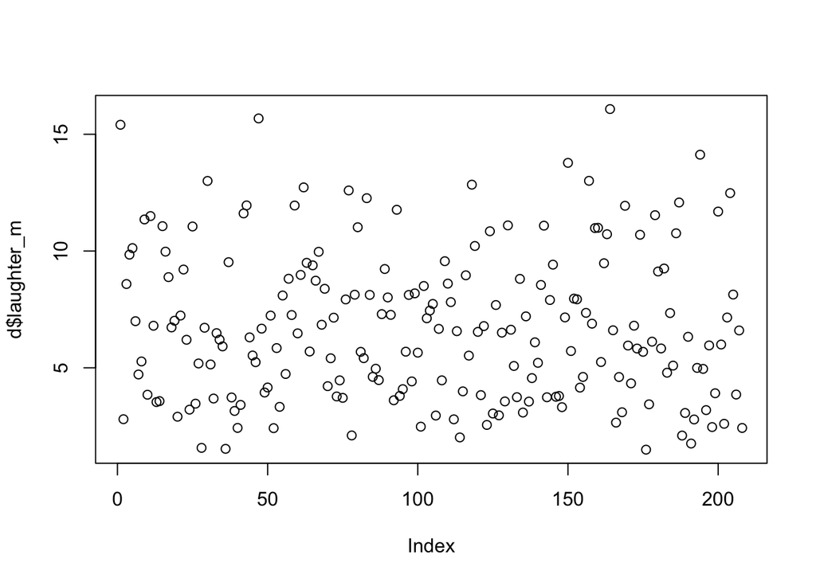

```r
d$laughter_m <-  varScore(d,
                        Forward = c('laughter1', 'laughter2', 'laughter3',
                                    'laughter4', 'laughter5', 'laughter7'),
                        Range = c(0,23.75),
                        Prorate = T,
                        MaxMiss = 0.25)/6

plot(d$laughter_m)
```

## 5.

Explore the dataframe by obtaining the bivariate correlations and scatterplot matrix on some of the variables of interest: laughter_m, liking, similarity, and drinks. Note any strong relationships between these variables.

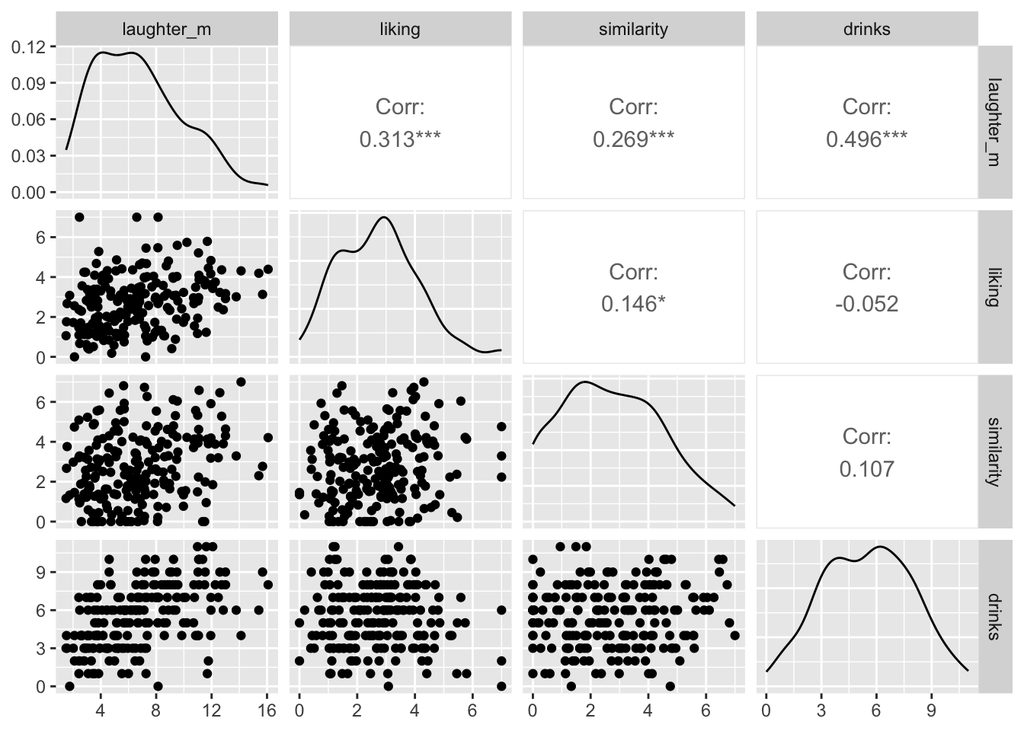

```r
GGally::ggpairs(d[, c("laughter_m", "liking", "similarity", "drinks")])
```

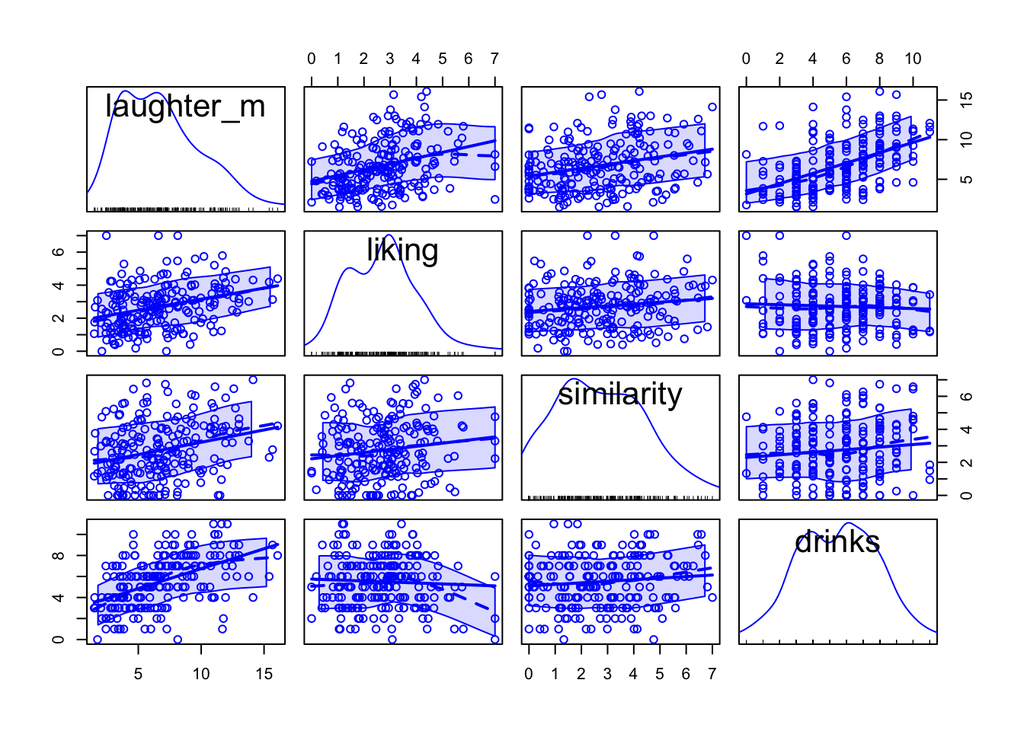

```r
spm(d[, c("laughter_m", "liking", "similarity", "drinks")])
```

> Drinks and laughter are strongly related, other variables less so. liking and similarity both related to laughter, but not strongly related to each other.

## 6.

Fit a model in which you predict the average laughter from drinking. In a sentence, describe your findings (report F, p values, and partial eta squared).

```r
m <- lm(laughter_m ~ drinks, data = d)
(m_sum = summary(m))
```

```
##
## Call:
## lm(formula = laughter_m ~ drinks, data = d)
##
## Residuals:
##     Min      1Q  Median      3Q     Max
## -5.2884 -1.9561 -0.4708  1.7039  8.3703
##
## Coefficients:
##             Estimate Std. Error t value Pr(>|t|)
## (Intercept)  3.15643    0.47638   6.626 2.96e-10 ***
## drinks       0.64962    0.07919   8.203 2.50e-14 ***
## ---
## Signif. codes:  0 '***' 0.001 '**' 0.01 '*' 0.05 '.' 0.1 ' ' 1
##
## Residual standard error: 2.771 on 206 degrees of freedom
## Multiple R-squared:  0.2462, Adjusted R-squared:  0.2426
## F-statistic: 67.29 on 1 and 206 DF,  p-value: 2.501e-14
```

```r
m_sum$coefficients[,"t value"]^2
```

```
## (Intercept)      drinks
##     43.9021     67.2935
```

```r
eta_squared(car::Anova(m, type = 3))
```

```
## For one-way between subjects designs, partial eta squared is equivalent
##   to eta squared. Returning eta squared.
```

```
## # Effect Size for ANOVA
##
## Parameter | Eta2 |       95% CI
## -------------------------------
## drinks    | 0.25 | [0.17, 1.00]
##
## - One-sided CIs: upper bound fixed at [1.00].
```

> Drinking more alcohol predicted more laughter

$b=.65, F(1,206)=67.29, p<.001, η2p=.25.$ > Each additional consumed drink was associated with laughing roughly half a second longer.

## 7.

What is the interpretation of the intercept in this model? Is this value meaningful? > The intercept (b0=3.16) is the laughter duration predicted by the model for a pair who did not consume any drinks that day. This is conceptually meaningful!

## 8.

Make a publication quality plot of the relationship between drinks and laughter. Below the plot, please describe what the error bands in your plot represent.

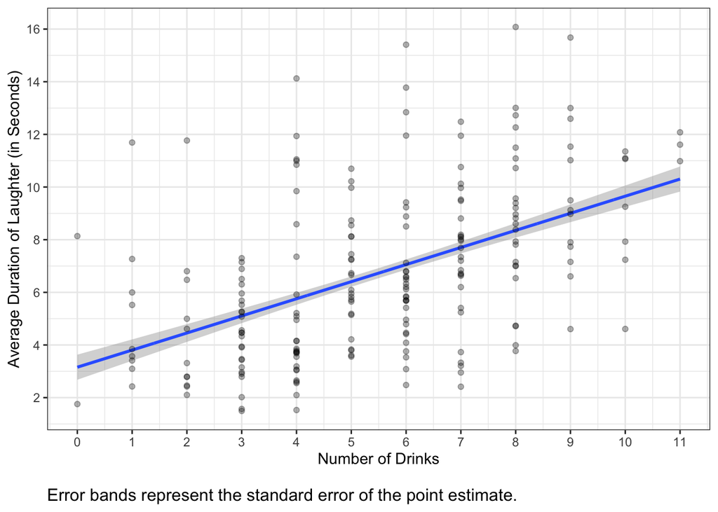

```r
min_drinks <- min(d$drinks, na.rm = T)
max_drinks <- max(d$drinks, na.rm = T)

d_graph <- data.frame(
  drinks = seq(from = min_drinks, to = max_drinks, length.out = 1000)
)

d_graph <- ggplotPredict(m, d_graph)

ggplot(d_graph, aes(x = drinks, y = Predicted)) +
  geom_smooth(stat = "identity", aes(ymin = CILo, ymax = CIHi)) +
  geom_point(data = d, aes(y = laughter_m), alpha = .3) +
  theme_bw() +
  labs(x = "Number of Drinks", y = "Average Duration of Laughter (in Seconds)") +
  scale_x_continuous(breaks = 0:11) +
  scale_y_continuous(breaks = seq(0, 18, by = 2)) +
  labs(caption="Error bands represent the standard error of the point estimate.") +
  theme(plot.caption=element_text(size=12, hjust=0, margin=margin(15,0,0,0)))
```

## 9.

Fit a model in which you predict the average laughter form drinking when controlling for the effect of similarity. In a sentence, describe your findings (report F, p values, and partial eta squared).

```r
m2 <- lm(laughter_m ~ drinks + similarity, data = d)
(m_sum2 = summary(m2))
```

```
##
## Call:
## lm(formula = laughter_m ~ drinks + similarity, data = d)
##
## Residuals:
##     Min      1Q  Median      3Q     Max
## -6.3643 -1.9663 -0.2761  1.3915  8.5369
##
## Coefficients:
##             Estimate Std. Error t value Pr(>|t|)
## (Intercept)  2.25316    0.52312   4.307 2.56e-05 ***
## drinks       0.61893    0.07732   8.005 8.75e-14 ***
## similarity   0.39290    0.10640   3.693 0.000284 ***
## ---
## Signif. codes:  0 '***' 0.001 '**' 0.01 '*' 0.05 '.' 0.1 ' ' 1
##
## Residual standard error: 2.689 on 205 degrees of freedom
## Multiple R-squared:  0.2932, Adjusted R-squared:  0.2863
## F-statistic: 42.53 on 2 and 205 DF,  p-value: 3.549e-16
```

```r
m_sum2$coefficients[,"t value"]^2
```

```
## (Intercept)      drinks  similarity
##    18.55169    64.08372    13.63662
```

```r
eta_squared(car::Anova(m2, type = 3))
```

```
## # Effect Size for ANOVA (Type III)
##
## Parameter  | Eta2 (partial) |       95% CI
## ------------------------------------------
## drinks     |           0.24 | [0.16, 1.00]
## similarity |           0.06 | [0.02, 1.00]
##
## - One-sided CIs: upper bound fixed at [1.00].
```

$b=.62, F(1,205) = 64.08, p<.001, η2p=.24.$ > Each additional consumed drink was associated with laughing roughly half a second longer, when controlling for the effect of similarity.

## 10.

Provide an interpretation for each of the parameter estimates for the model you fit in question 9. You answer must include a b value and a description that can be understood by someone who is not a statistician.

> b0 = 2.25, this is the predicted number of seconds spent laughing for a person who has had no drinks and has a similarity score of 0. b1 = 0.62, this is the predicted number of additional seconds spent laughing for each drink consumed, when controlling for the effects of similarity. b2 = 0.39, this is the predicted number of additional seconds spent laughing for a 1 unit increase in similarity, when controlling for the effects of drinking.